# DoReMiTra Use Case

Bioinformatics Group, IMBEI, University Medical Center Mainz

Author

Affiliations

Ahmed Salah

Department of Radiation Oncology and Radiation Therapy, Mainz, Germany

Institute of Medical Biostatistics, Epidemiology and Informatics (IMBEI), Mainz, Germany

Published

December 11, 2025

# 1 Loading the libraries

```r
library("DoReMiTra")
library("mosdef")
library("org.Hs.eg.db")
library("DESeq2")
library("ggplot2")
library("ComplexHeatmap")
library("VennDiagram")
library("limma")
library("circlize")
library("GeneTonic")
library("clusterProfiler")
```

# 2 Searching Datasets

The user can use **`search_DoReMiTra_datasets()`** to filter the available DoReMiTra datasets based on metadata fields such as radiation type, organism, or experimental setting. This function helps narrow down datasets of interest before fetching them.

```r
# X-ray datasets
search_DoReMiTra_datasets(radiation_type = "X-ray",
                          organism = "Homo sapiens",
                          exp_setting = "ExVivo")
```

```
#> Filtering for radiation type: X-ray
#> Filtering for organism: Homo sapiens
#> Filtering for experimental setting: ExVivo
#>
#> Matching datasets found: 4
#> To retrieve one or more of these datasets, you can use:
#> se_name1 <- get_DoReMiTra_data("SE_Broustas_2017_ExVivo_GSE90909_GPL13497")
#> se_name2 <- get_DoReMiTra_data("SE_Ghandhi_2015_ExVivo_GSE65292_GPL13497")
#>
#> For more details, please refer to `?get_DoReMiTra_data`
#> [1] "SE_Broustas_2017_ExVivo_GSE90909_GPL13497"
#> [2] "SE_Ghandhi_2015_ExVivo_GSE65292_GPL13497"
#> [3] "SE_Flores_2009_ExVivo_GSE15341_GPL8332"
#> [4] "SE_Salah_2025_ExVivo"
```

```r
# gamma ray datasets
search_DoReMiTra_datasets(radiation_type = "gamma ray",
                          organism = "Homo sapiens",
                          exp_setting = "ExVivo")
```

```
#> Filtering for radiation type: gamma ray
#> Filtering for organism: Homo sapiens
#> Filtering for experimental setting: ExVivo
#>
#> Matching datasets found: 14
#> To retrieve one or more of these datasets, you can use:
#> se_name1 <- get_DoReMiTra_data("SE_Park_2017_ExVivo_GSE102971_GPL10332_HomoSapiens")
#> se_name2 <- get_DoReMiTra_data("SE_Vasilyev_2017_ExVivo_GSE97000_GPL17077")
#>
#> For more details, please refer to `?get_DoReMiTra_data`
#>  [1] "SE_Park_2017_ExVivo_GSE102971_GPL10332_HomoSapiens"
#>  [2] "SE_Vasilyev_2017_ExVivo_GSE97000_GPL17077"
#>  [3] "SE_Paul_2013_ExVivo_GSE44201_GPL6480"
#>  [4] "SE_Paul_2013_ExVivo_GSE44201_GPL6848"
#>  [5] "SE_Nosel_2013_ExVivo_GSE43151_GPL13497"
#>  [6] "SE_Girardi_2012_ExVivo_GSE20173_GPL6480"
#>  [7] "SE_Amundson_2011_ExVivo_GSE23515_GPL6480"
#>  [8] "SE_Gruel_2008_ExVivo_GSE6978_GPL4803"
#>  [9] "SE_Rouchka_2019_ExVivo_GSE63952_GPL15207"
#> [10] "SE_Amundson_2008_ExVivo_GSE8917_GPL1708"
#> [11] "SE_Manikandan_2014_ExVivo_GSE36355_GPL6883"
#> [12] "SE_Lee_2013_ExVivo_GSE44245_GPL570"
#> [13] "SE_Rouchka_2015_ExVivo_GSE64375_GPL6244"
#> [14] "SE_Ankermit_2015_ExVivo_GSE55953_GPL14550"
```

# 3 Fetching Datasets

After selecting the dataset of interest, **`get_DoReMiTra_data()`** can be used to fetch a `SummarizedExperiment` (SE) object directly from ExperimentHub.

```r
dataset_name_1 <- "SE_Salah_2025_ExVivo"

# we would like also to compare it to another dataset from another radiation type to see shared and distinct gene signatures

dataset_name_2 <- "SE_Paul_2013_ExVivo_GSE44201_GPL6848"


se1 <- get_DoReMiTra_data(dataset_name_1)
```

```
#> see ?DoReMiTra and browseVignettes('DoReMiTra') for documentation
#> loading from cache
```

```r
se2 <- get_DoReMiTra_data(dataset_name_2, gene_symbol = TRUE)
```

```
#> see ?DoReMiTra and browseVignettes('DoReMiTra') for documentation
#> loading from cache
```

# 4 Summarizing a Dataset

To quickly obtain a summary of an SE object, use **`summarize_DoReMiTra_se()`**, which provides a concise overview including the number of samples, genes, radiation types, and other metadata.

```r
summarize_DoReMiTra_se(se1)
```

```
#> This dataset is generated by: Salah
#>     Platform: RNAseq
#>     Organism(s): Homo sapiens
#>     Radiation Type: X-ray
#>     Experiment Setting: ExVivo
#>     Number of Samples: 30
#>     Accession: NA
#>     For more information about this study, please check:
#> https://github.com/AhmedSAHassan/Phybion_ShortReads_Analysis
```

# 5 Comparing the metadata of multiple Datasets

To compare key metadata information from two or more SE objects from the DoReMiTra collection, **`compare_DoReMiTra_datasets()`** summarizes key metadata information such as radiation type, dose, and time point.

```r
se_list<- list(
  Salah = se1,
  Paul = se2
)
compare_DoReMiTra_datasets(se_list = se_list) |> kableExtra::kable()
```

```
#> systemfonts and textshaping have been compiled with different versions of Freetype. Because of this, textshaping will not use the font cache provided by systemfonts
```

|  | Salah | Paul |
| --- | --- | --- |
| Radiation_type | X-ray | gamma ray |
| Dose | 0.5Gy, 0Gy, 1Gy, 2Gy, 4Gy | 0.5Gy, 0Gy, 2Gy, 5Gy, 8Gy |
| Sex | Female, Male | female, male |
| Time_point | 2hrs, 6hrs | 24hr, 6hr |
| Organism | Homo sapiens | Homo sapiens |
| Sample_number | 30 | 50 |

# 6 Once we retrieved the analysis-ready datasets of intereset, we can explore and analyse them

## 6.1 X-ray dataset analysis

```r
# This dataset consists of 3 donors, 5 doses (0, 0.5, 1, 2, and 4Gy), and 2 timepoints (2h and 6h)

dds<- DESeqDataSet(se1, design = ~ +1)
```

```
#> using counts and average transcript lengths from tximeta
```

```r
dds$Dose <- factor(dds$Dose)

dds$Donors <- factor(dds$Donors)

dds$Dose <- relevel(dds$Dose, ref = "0Gy")

dds_t1 <- dds[, dds$Time_point == "2hrs"]

dds_t2 <- dds[, dds$Time_point == "6hrs"]


vsd_Salah <- vst(dds)
```

```
#> using 'avgTxLength' from assays(dds), correcting for library size
```

```r
pca_plot <- plotPCA(vsd_Salah,
                    intgroup = c("Donors", "Time_point"),
                    returnData = TRUE)
```

```
#> using ntop=500 top features by variance
```

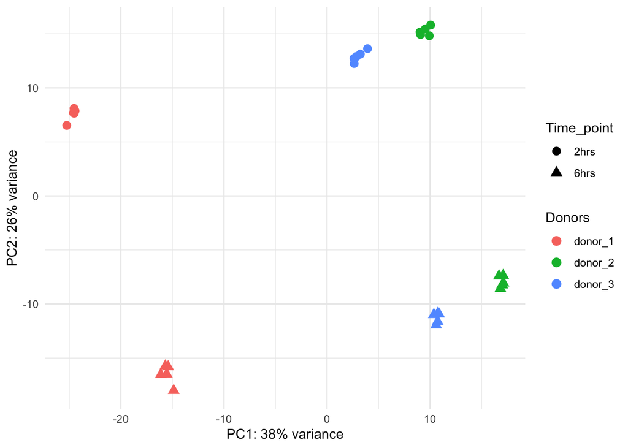

```r
percentVar <- round(100 * attr(pca_plot, "percentVar"))

PCA<- ggplot(pca_plot, aes(x = PC1, y = PC2, color = Donors, shape = Time_point)) +
  geom_point(size = 3) +
  scale_shape_manual(values = c(16, 17)) +
  xlab(paste0("PC1: ", percentVar[1], "% variance")) +
  ylab(paste0("PC2: ", percentVar[2], "% variance")) +
  theme_minimal()+
  theme(plot.background = element_rect(fill = "white", color = NA))

PCA
```

Heatmap of the highly variable genes

```r
vsd_t1 <- vst(dds_t1)
```

```
#> using 'avgTxLength' from assays(dds), correcting for library size
```

```r
# as we have strong donor effect, we will account for it for better visualization

vsd_corrected <- vsd_t1
assay(vsd_corrected) <- limma::removeBatchEffect(assay(vsd_corrected), batch = vsd_corrected$Donors)
```

```
#> design matrix of interest not specified. Assuming a one-group experiment.
```

```r
# Order columns by dose
doses <- as.numeric(sub("Gy.*", "", colnames(vsd_corrected)))
col_order <- order(doses)
vsd_corrected <- vsd_corrected[, col_order]

colnames(vsd_corrected)
```

```
#>  [1] "0Gy-2hrs-do1"   "0Gy-2hrs-do2"   "0Gy-2hrs-do3"   "0.5Gy-2hrs-do1"
#>  [5] "0.5Gy-2hrs-do2" "0.5Gy-2hrs-do3" "1Gy-2hrs-do1"   "1Gy-2hrs-do2"
#>  [9] "1Gy-2hrs-do3"   "2Gy-2hrs-do1"   "2Gy-2hrs-do2"   "2Gy-2hrs-do3"
#> [13] "4Gy-2hrs-do1"   "4Gy-2hrs-do2"   "4Gy-2hrs-do3"
```

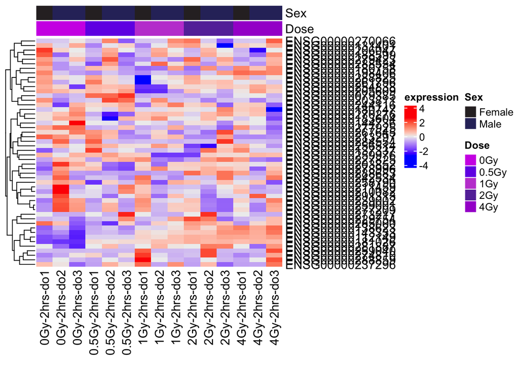

```r
top_n <- 50

rv <- rowVars(assay(vsd_corrected))
top_genes <- order(rv, decreasing = TRUE)[1:top_n]

mat <- assay(vsd_corrected)[top_genes, ]
mat_scaled <- t(scale(t(mat)))
annotation <- as.data.frame(colData(vsd_corrected)[, c("Sex","Dose"), drop = FALSE])


Heatmap(mat_scaled,
        name = "expression",
        cluster_columns = F,
        top_annotation = HeatmapAnnotation(df = annotation))
```

Alternatively, one can also explore the datasets with DoReMiTraExplorer

The retrieved SE objects can be explored with **`DoReMiTra_explorer()`**, an interactive Shiny application for visualization and exploratory analysis of DoReMiTra datasets. This app allows users to examine transcriptomic responses to radiation using:

- Principal component analysis (PCA)
- Boxplots
- Dose–response gene plots
- Heatmaps of highly variable genes

It provides flexibility for both high-level overviews and detailed inspection of radiation-induced transcriptional patterns.